# Practical Machine Learning: Prediction Assignment Writeup

Michal Smolira

27.10.2017

## Overview

Background

Using devices such as Jawbone Up, Nike FuelBand, and Fitbit it is now possible to collect a large amount of data about personal activity relatively inexpensively. These type of devices are part of the quantified self movement – a group of enthusiasts who take measurements about themselves regularly to improve their health, to find patterns in their behavior, or because they are tech geeks. One thing that people regularly do is quantify how much of a particular activity they do, but they rarely quantify how well they do it. In this project, your goal will be to use data from accelerometers on the belt, forearm, arm, and dumbell of 6 participants. They were asked to perform barbell lifts correctly and incorrectly in 5 different ways. More information is available from the website here: http://web.archive.org/web/20161224072740/http:/groupware.les.inf.puc-rio.br/har (see the section on the Weight Lifting Exercise Dataset).

Data

The training data for this project are available here:

https://d396qusza40orc.cloudfront.net/predmachlearn/pml-training.csv

The test data are available here:

https://d396qusza40orc.cloudfront.net/predmachlearn/pml-testing.csv

The data for this project come from this source: http://web.archive.org/web/20161224072740/http:/groupware.les.inf.puc-rio.br/har. If you use the document you create for this class for any purpose please cite them as they have been very generous in allowing their data to be used for this kind of assignment.

## Data Preparation

FIrst we load the data from above urls . At first glance we see that there is many fields with blank space , and few with value ,“#DIV/0” so both we change to NA values

```r
pml_training<-read.csv(url("https://d396qusza40orc.cloudfront.net/predmachlearn/pml-training.csv"),na.strings=c("","NA","#DIV/0"))

pml_testing<-read.csv(url("https://d396qusza40orc.cloudfront.net/predmachlearn/pml-testing.csv"),na.strings=c("","NA","#DIV/0"))
```

Calculate percent of NA values for each column

```r
Columquality<-colSums(is.na(pml_training))/nrow(pml_training)
```

Remove columns with more than 5% NA Values

```r
pml_training<-pml_training[Columquality<0.05]
pml_testing<-pml_testing[Columquality<0.05]
```

Remove first 7 columns which describe the data rows

```r
pml_training<-pml_training[,-c(1:7)]
pml_testing<-pml_testing[,-c(1:7)]
```

```r
dim(pml_training)
```

```
## [1] 19622    53
```

The final training dataset has 19622 rows and 53 variables. We have 52 predictors

## Cross- Validation

The training dataset will be divide to two data set * Training (70% of original pml_training) * Validation (30% of original pml_training)

```r
set.seed(1109)

library(caret)
inTrain <- createDataPartition(y=pml_training$classe,p=0.7,list=FALSE)

training<- pml_training[inTrain,]

validation<-pml_training[-inTrain,]
```

## Model Chose

### Because predicting value is a factor we start building models from Decision Trees

```r
library(rpart)

ModelTrees<- rpart(classe~.,data = training,method = "class")

library(rattle)
```

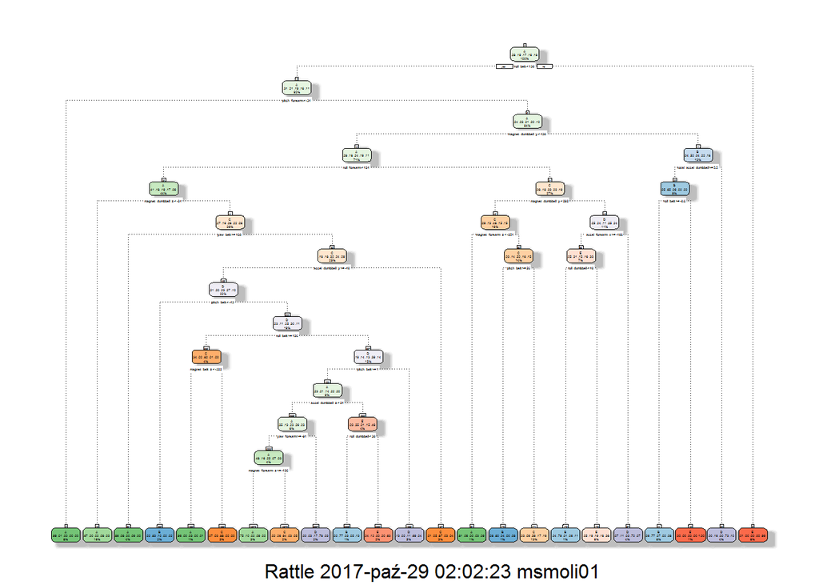

```r
fancyRpartPlot(ModelTrees)
```

```r
predictTrees<-predict(ModelTrees,newdata = validation,type = "class")


confusionMatrix(predictTrees,validation$classe)
```

```
## Confusion Matrix and Statistics
##
##           Reference
## Prediction    A    B    C    D    E
##          A 1502  244   23  114   50
##          B   43  637   55   25   66
##          C   49  102  829  148  125
##          D   51   80   55  599   55
##          E   29   76   64   78  786
##
## Overall Statistics
##
##                Accuracy : 0.7397
##                  95% CI : (0.7283, 0.7509)
##     No Information Rate : 0.2845
##     P-Value [Acc > NIR] : < 2.2e-16
##
##                   Kappa : 0.6691
##  Mcnemar's Test P-Value : < 2.2e-16
##
## Statistics by Class:
##
##                      Class: A Class: B Class: C Class: D Class: E
## Sensitivity            0.8973   0.5593   0.8080   0.6214   0.7264
## Specificity            0.8976   0.9602   0.9127   0.9510   0.9486
## Pos Pred Value         0.7770   0.7712   0.6616   0.7131   0.7609
## Neg Pred Value         0.9565   0.9008   0.9575   0.9277   0.9390
## Prevalence             0.2845   0.1935   0.1743   0.1638   0.1839
## Detection Rate         0.2552   0.1082   0.1409   0.1018   0.1336
## Detection Prevalence   0.3285   0.1404   0.2129   0.1427   0.1755
## Balanced Accuracy      0.8975   0.7597   0.8604   0.7862   0.8375
```

**Accuracy for decision Trees is 0.7397**

### The second model use Random forest method

```r
library(randomForest)
RandomForest <- randomForest(classe ~ ., data = training)

predictRF<-predict(RandomForest,newdata = validation)


confusionMatrix(predictRF,validation$classe)
```

```
## Confusion Matrix and Statistics
##
##           Reference
## Prediction    A    B    C    D    E
##          A 1672    2    0    0    0
##          B    1 1134    5    0    0
##          C    0    3 1019   12    1
##          D    0    0    2  951    2
##          E    1    0    0    1 1079
##
## Overall Statistics
##
##                Accuracy : 0.9949
##                  95% CI : (0.9927, 0.9966)
##     No Information Rate : 0.2845
##     P-Value [Acc > NIR] : < 2.2e-16
##
##                   Kappa : 0.9936
##  Mcnemar's Test P-Value : NA
##
## Statistics by Class:
##
##                      Class: A Class: B Class: C Class: D Class: E
## Sensitivity            0.9988   0.9956   0.9932   0.9865   0.9972
## Specificity            0.9995   0.9987   0.9967   0.9992   0.9996
## Pos Pred Value         0.9988   0.9947   0.9845   0.9958   0.9981
## Neg Pred Value         0.9995   0.9989   0.9986   0.9974   0.9994
## Prevalence             0.2845   0.1935   0.1743   0.1638   0.1839
## Detection Rate         0.2841   0.1927   0.1732   0.1616   0.1833
## Detection Prevalence   0.2845   0.1937   0.1759   0.1623   0.1837
## Balanced Accuracy      0.9992   0.9972   0.9949   0.9929   0.9984
```

## Summary

```r
finalcheck <- predict(RandomForest, newdata = pml_testing, type="class")
finalcheck
```

```
##  1  2  3  4  5  6  7  8  9 10 11 12 13 14 15 16 17 18 19 20
##  B  A  B  A  A  E  D  B  A  A  B  C  B  A  E  E  A  B  B  B
## Levels: A B C D E
```